# Systematicity across grammatical category and other lexical features

# Introduction

This report investigates whether the **sub-morphemic form-meaning systematicity** of different words correlates with various lexical features, including grammatical category, age of acquisition, and word frequency.

Previous work ([Monaghan et al, 2014](http://rstb.royalsocietypublishing.org/content/369/1651/20130299.short)) has found that age of acquisition (AoA) predicts systematicity, above and beyond other variables like orthographic/phonological length. Specifically, earlier-acquired words were more systematic.

# Dataset

```r
setwd("/Users/strott/nlp/systematicity/")
```

## Systematicity of individual words

```r
setwd("/Users/strott/nlp/systematicity/")
word_systematicity_scores = read_csv("data/processed/all_words_systematicity.csv")
```

We calculated the systematicity of each word following the same procedure as [Monaghan et al, 2014](http://rstb.royalsocietypublishing.org/content/369/1651/20130299.short). The Jupyter notebook containing this analysis can be found [here](https://github.com/seantrott/systematicity/blob/master/systematicity_by_word_class.ipynb). We obtained monosyllabic, monomorphemic words from CELEX, then filtered on the words that appeared in the Google News word embeddings, resulting in 2082 words overall.

We then calculated a **global correlation** score between the *form* and *meaning* distances of each wordpair. To obtain by-word systematicity scores, we compared this global correlation to the correlation coefficient when omitting a particular word: the difference in scores is deemed the *contribution* a given word makes to a lexicon’s global systematicity.

The distribution of systematicity scores is plotted below:

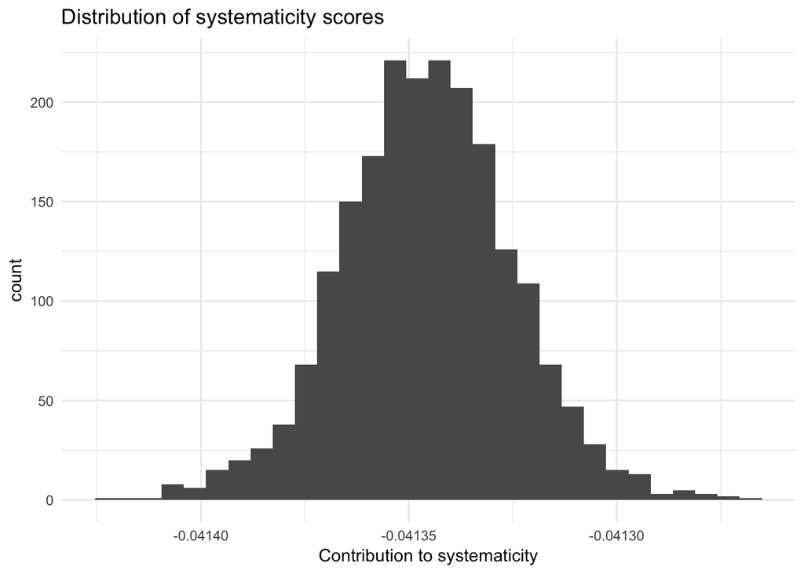

```r
word_systematicity_scores %>%
  ggplot(aes(x = impact)) +
  geom_histogram() +
  labs(x = "Contribution to systematicity",
       title = "Distribution of systematicity scores") +
  theme_minimal()
```

## Age of Acquisition data

```r
setwd("/Users/strott/nlp/systematicity/")
aoa_kuperman = read_csv("data/raw/AoA_Kuperman.csv")
aoa_kuperman$word = aoa_kuperman$Word
```

For AoA data, we used the same dataset that [Monaghan et al, 2014](http://rstb.royalsocietypublishing.org/content/369/1651/20130299.short) used, collected by [Kuperman et al (2012)](http://crr.ugent.be/archives/806).

There are scores for 31124 words overall.

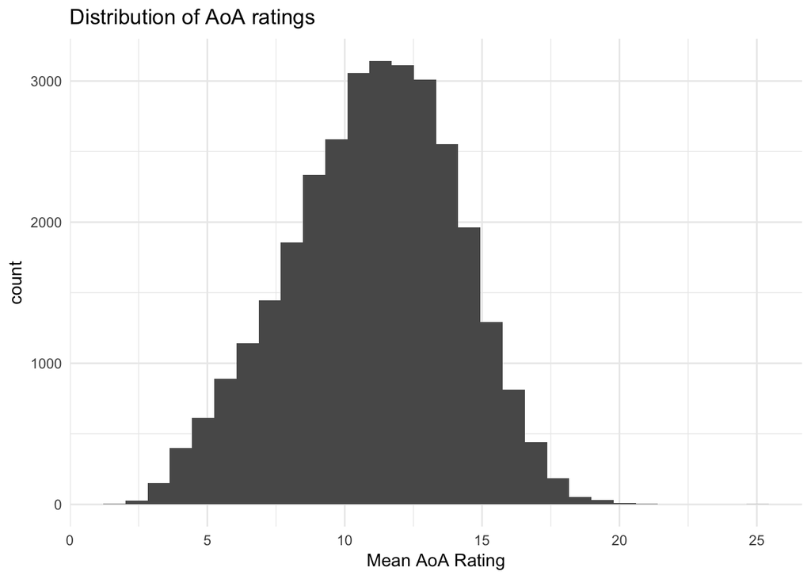

```r
aoa_kuperman %>%
  ggplot(aes(x = Rating.Mean)) +
  geom_histogram() +
  labs(x = "Mean AoA Rating",
       title = "Distribution of AoA ratings") +
  theme_minimal()
```

## Word class data

```r
setwd("/Users/strott/nlp/systematicity/")
word_classes = read.csv("data/raw/celex_classes.csv", sep="\\")
word_classes$word = word_classes$Word
```

Finally, we used [WebCelex](http://celex.mpi.nl/) to grab information about the word class and frequency of all monomorphemic, monosyllabic words. There is information for 6760 overall.

```r
table(word_classes$Class)
```

```
##
##         A  ADV  ART    C    I    N  NUM PREP PRON    V
##  220  531  184    4   25   97 3575   21   44   65 1994
```

As [Monaghan et al 2014](http://rstb.royalsocietypublishing.org/content/369/1651/20130299.short) do, we remove words with more than one word class:

```r
word_classes$duplicate = duplicated(word_classes$Word)

duplicate_words = filter(word_classes, duplicate==TRUE)$Word
word_classes_filtered = filter(word_classes, (Word %in% duplicate_words) == FALSE)
```

## Combining all together

Finally, we merged each of these datasets together:

```r
merged = merge(word_systematicity_scores, aoa_kuperman, on="word")
merged_all = merge(merged, distinct(word_classes_filtered), on="word")
```

This results in only 784 observations.

# Results

Our chief question is whether the **systematicity** of a word is related to its:

- Grammatical Class
- Age of Acquisition
- Frequency
- Length

To answer this, we regressed *systematicity* in a standard OLS regression against each of those variables:

```r
model_omnibus = lm(data = merged_all,
                   impact ~ Rating.Mean + Class + CobLog + word_length)
summary(model_omnibus)
```

```
##
## Call:
## lm(formula = impact ~ Rating.Mean + Class + CobLog + word_length,
##     data = merged_all)
##
## Residuals:
##        Min         1Q     Median         3Q        Max
## -8.120e-05 -1.287e-05 -7.230e-07  1.333e-05  7.869e-05
##
## Coefficients:
##               Estimate Std. Error   t value Pr(>|t|)
## (Intercept) -4.135e-02  6.033e-06 -6853.733   <2e-16 ***
## Rating.Mean  1.890e-08  3.179e-07     0.059   0.9526
## ClassADV    -5.291e-06  1.093e-05    -0.484   0.6285
## ClassC       3.603e-05  2.124e-05     1.696   0.0902 .
## ClassI       1.724e-05  2.138e-05     0.807   0.4202
## ClassN      -3.580e-06  2.644e-06    -1.354   0.1762
## ClassPREP    2.029e-05  2.154e-05     0.942   0.3464
## ClassPRON    9.943e-06  9.489e-06     1.048   0.2950
## ClassV      -3.998e-06  3.065e-06    -1.305   0.1924
## CobLog      -1.256e-07  1.413e-06    -0.089   0.9292
## word_length  1.208e-06  8.532e-07     1.416   0.1572
## ---
## Signif. codes:  0 '***' 0.001 '**' 0.01 '*' 0.05 '.' 0.1 ' ' 1
##
## Residual standard error: 2.104e-05 on 773 degrees of freedom
## Multiple R-squared:  0.0149, Adjusted R-squared:  0.002156
## F-statistic: 1.169 on 10 and 773 DF,  p-value: 0.3082
```

Unlike Monaghan et al (2014), we don’t see a significant relationship between AoA and systematicity. This is also evident if we visualize that relationship:

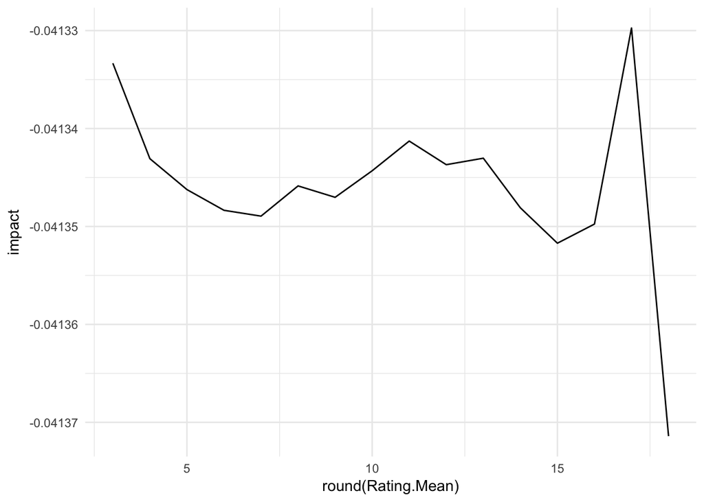

```r
merged_all %>%
  ggplot(aes(x = round(Rating.Mean),
             y = impact)) +
  geom_line(stat = "summary", fun.y = "mean") +
  theme_minimal()
```

# Next Steps

In order, it seems like we ought to:

- Do further validation of the dataset, to account for the divergence in results from Monaghan et al, 2014.
- Look at other lexical features.
- Look across languages.